# AIDS Drug

Demian Romero

11/18/2019

# 1 Introduction

A new preventative for aids (abacavirinol) is under test in clinical trials. We analyzed the effectiveness of this drug across population subgroups including gender, drug use, and sexual orientation.

The first question this: does abacavirinol have any affect on whether one contracts AIDS or not?

$H_0:$ Abacavirinol has no effect on whether one contracts AIDS or not.  
$H_1:$ Abacavirinol has an effect on whether one contracts AIDS or not.

The second question is:does abacavirinol have a different affect based on gender?

$H_0:$ Gender has no effect on whether abacavirinol offers any protection agains contracting AIDS.

The third question is:does abacavirinol have a different affect based on drug use?

$H_0:$ Drug use has no effect on whether abacavirinol offers any protection agains contracting AIDS.

The final question is:does abacavirinol have a different affect based on sexual orientation?

$H_0:$ sexual orientation has no effect on whether abacavirinol offers any protection against contracting AIDS.

# 2 Methods

For each hypothesis test the graphical summary will be a bar plot, the numerical summary will be a cross tabulation, and a chi-squared test will be used for the inferential results.

# 3 Results General Population

is the vaccine effective in the general population?

## 3.1 Descriptive Results

We use a bar chart to show the effectiveness of the vaccine on the general population.

### 3.1.1 Graphical Descriptive Results

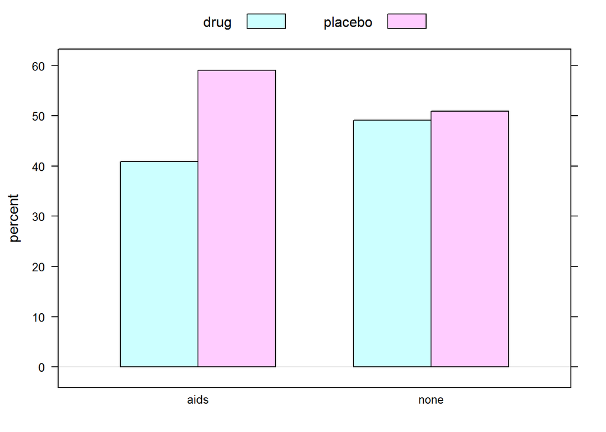

```r
barchartGC(~infected+treatment, data=avast, type="percent")
```

The barchart shows that the people that received the vaccine are less likely to contract AIDS if they receive the vaccine.

### 3.1.2 Numerical Descriptive Results

```r
genTable = xtabs(~infected+treatment, data=avast)
print(genTable)
```

```
##         treatment
## infected  drug placebo
##     aids   423     612
##     none 10168   10540
```

## 3.2 Inferential Results

```r
chisqtestGC(genTable)
```

```
## Pearson's Chi-squared test with Yates' continuity correction
##
## Observed Counts:
##         treatment
## infected  drug placebo
##     aids   423     612
##     none 10168   10540
##
## Counts Expected by Null:
##         treatment
## infected     drug  placebo
##     aids   504.15   530.85
##     none 10086.85 10621.15
##
## Contributions to the chi-square statistic:
##         treatment
## infected  drug placebo
##     aids 13.06   12.40
##     none  0.65    0.62
##
##
## Chi-Square Statistic = 26.4104
## Degrees of Freedom of the table = 1
## P-Value = 0
```

```r
fisher.test(genTable)
```

```
##
##  Fisher's Exact Test for Count Data
##
## data:  genTable
## p-value = 2.333e-07
## alternative hypothesis: true odds ratio is not equal to 1
## 95 percent confidence interval:
##  0.6295438 0.8148378
## sample estimates:
## odds ratio
##  0.7164774
```

This table shows that people whom receive the vaccine are slightly less likely to contract AIDS if they receive the vaccine.

# 4 Results Gender Effects

Does gender have an effect on vaccine effectiveness?

## 4.1 Descriptive Results for Gender

We use a bar chart to show the effectiveness of the vaccine on the general population, allowing for Gender.

### 4.1.1 Graphical Descriptive Results for Gender

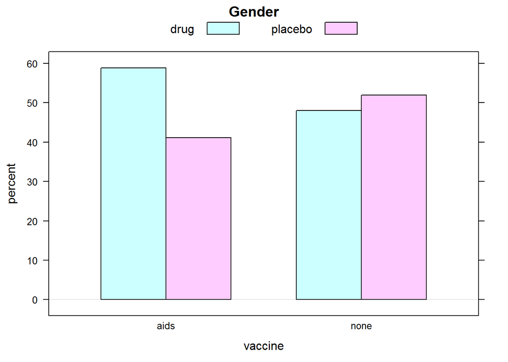

```r
barchartGC(~infected+treatment, data=avastGender, type="percent", xlab='vaccine', main="Gender")
```

### 4.1.2 Numerical Descriptive Results

```r
xtabs(~infected+treatment, data=avastGender)
```

```
##         treatment
## infected drug placebo
##     aids  210     147
##     none 5484    5927
```

## 4.2 Inferential Results

```r
chisqtestGC(~infected+treatment, data=avastGender)
```

```
## Pearson's Chi-squared test with Yates' continuity correction
##
## Observed Counts:
##         treatment
## infected drug placebo
##     aids  210     147
##     none 5484    5927
##
## Counts Expected by Null:
##         treatment
## infected    drug placebo
##     aids  172.74  184.26
##     none 5521.26 5889.74
##
## Contributions to the chi-square statistic:
##         treatment
## infected drug placebo
##     aids 8.04    7.54
##     none 0.25    0.24
##
##
## Chi-Square Statistic = 15.6339
## Degrees of Freedom of the table = 1
## P-Value = 1e-04
```

# 5 Results IV Drug Use

Does IV Drug use have an effect on vaccine effectiveness?

## 5.1 Descriptive Results for IV Drug Use

We use a bar chart to show the effectiveness of the vaccine among IV Drug Users.

### 5.1.1 Graphical Descriptive Results for IV Drug Use

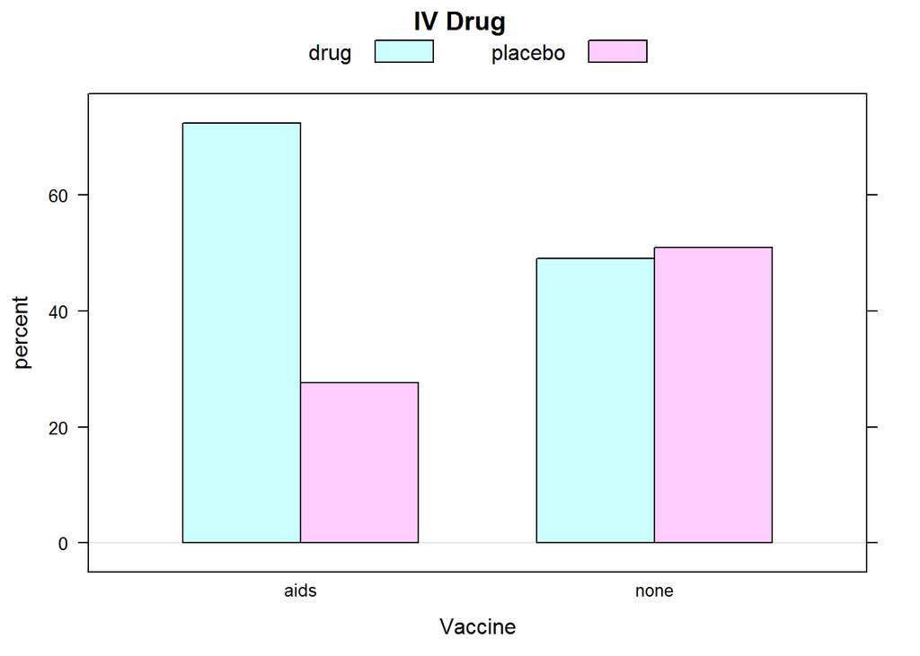

```r
barchartGC(~infected+treatment, data=avastIV, type="percent", xlab='Vaccine', main='IV Drug')
```

### 5.1.2 Numerical Descriptive Results

```r
genTable = xtabs(~infected+treatment, data=avastIV)
print(genTable)
```

```
##         treatment
## infected drug placebo
##     aids   76      29
##     none 1007    1046
```

## 5.2 Inferential Results

```r
chisqtestGC(~infected+treatment, data=avastIV)
```

```
## Pearson's Chi-squared test with Yates' continuity correction
##
## Observed Counts:
##         treatment
## infected drug placebo
##     aids   76      29
##     none 1007    1046
##
## Counts Expected by Null:
##         treatment
## infected    drug placebo
##     aids   52.69   52.31
##     none 1030.31 1022.69
##
## Contributions to the chi-square statistic:
##         treatment
## infected  drug placebo
##     aids 10.31   10.38
##     none  0.53    0.53
##
##
## Chi-Square Statistic = 20.8264
## Degrees of Freedom of the table = 1
## P-Value = 0
```

```r
fisher.test(genTable)
```

```
##
##  Fisher's Exact Test for Count Data
##
## data:  genTable
## p-value = 2.998e-06
## alternative hypothesis: true odds ratio is not equal to 1
## 95 percent confidence interval:
##  1.735490 4.369508
## sample estimates:
## odds ratio
##   2.720997
```

# 6 Results Sexual Orientation

Does sexual orientation have an effect on vaccine effectiveness?

## 6.1 Descriptive Results for Sexual Orientation

We use a bar chart to show the effectiveness of the vaccine on the general population allowing for Sexual Orientation.

### 6.1.1 Graphical Descriptive Results for Sexual Orientation

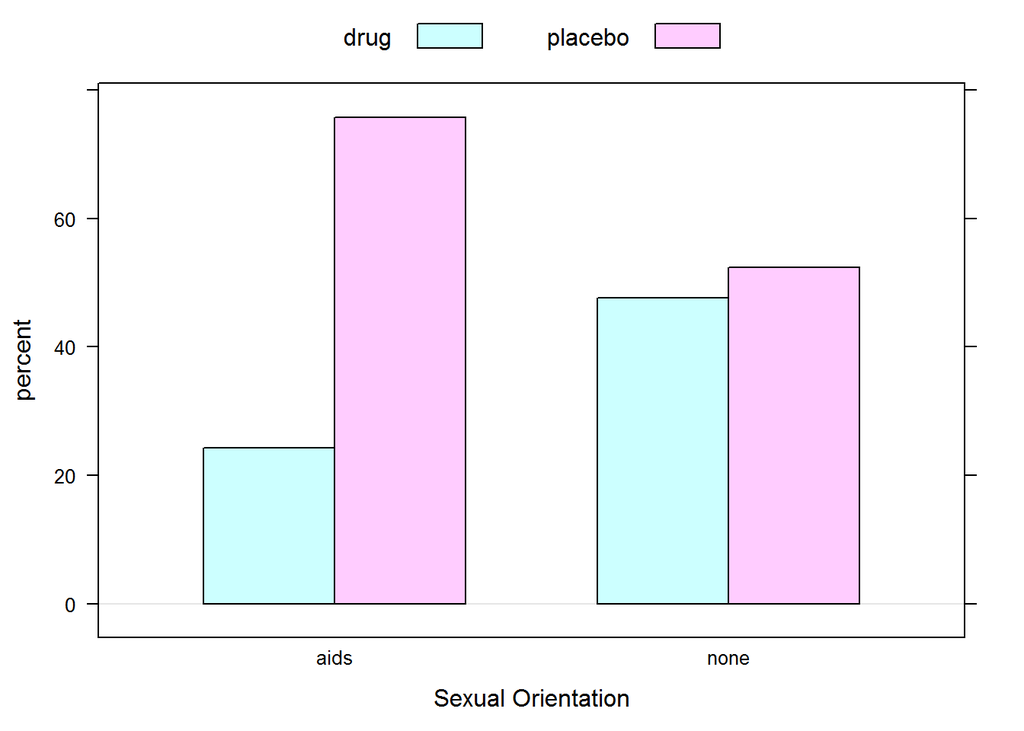

```r
barchartGC(~infected+treatment, data=avastLBGT, type="percent", xlab='Sexual Orientation')
```

### 6.1.2 Numerical Descriptive Results

```r
genTable2 = xtabs(~infected+treatment, data=avastLBGT)
print(genTable2)
```

```
##         treatment
## infected drug placebo
##     aids   34     106
##     none 1143    1259
```

## 6.2 Inferential Results

```r
chisqtestGC(~infected+treatment, data=avastLBGT)
```

```
## Pearson's Chi-squared test with Yates' continuity correction
##
## Observed Counts:
##         treatment
## infected drug placebo
##     aids   34     106
##     none 1143    1259
##
## Counts Expected by Null:
##         treatment
## infected    drug placebo
##     aids   64.82   75.18
##     none 1112.18 1289.82
##
## Contributions to the chi-square statistic:
##         treatment
## infected  drug placebo
##     aids 14.66   12.64
##     none  0.85    0.74
##
##
## Chi-Square Statistic = 27.955
## Degrees of Freedom of the table = 1
## P-Value = 0
```

```r
fisher.test(genTable2)
```

```
##
##  Fisher's Exact Test for Count Data
##
## data:  genTable2
## p-value = 4.23e-08
## alternative hypothesis: true odds ratio is not equal to 1
## 95 percent confidence interval:
##  0.2308342 0.5294225
## sample estimates:
## odds ratio
##  0.3534128
```

# 7 Final Discussion and Conclusions

OVERALL Null hypothesis is that the vaccine has no effect on the general infected population.

The p-value was 0,so we reject the null hypothesis which is smaller than .05. Because the response and explanatory values are categorical, the bar plot and chi-square test for independence.